# Analítica Avanzada de Datos

- Mostrar todo el código
- Ocultar todo el código
- Ver el código fuente

Caso #1

Autor/a

Afiliación

[Jorge I. Vélez, PhD - Julian Acevedo](https://jorgeivanvelez.netlify.app/)

Universidad del Norte, Barranquilla

Fecha de publicación

18 de mayo de 2024

### Importante

1. El puntaje asociado a cada conjunto de preguntas se encuentra entre ().
2. **Pueden utilizarse herramientas y/o conceptos de otras asignaturas** en caso de ser necesario.
3. Tenga en cuenta que aunque los cálculos son importantes, el **análisis e interpretación** tendrán un mayor peso en la calificación.
4. La solución debe enviarse en formato `HTML` a jvelezv@uninorte.edu.co a más tardar el **Viernes 31 de Mayo de 2024 a las 2 PM**.

## Contexto Analítico

Un grupo de investigación de una prestigiosa Universidad estudia una transtorno del neurodesarollo que se presenta principalmente en niños.

Los datos pueden leerse en `R` haciendo:

**Código**

```r
## data set
x <- read.table('https://tinyurl.com/PsychoDB',
                sep = ',', header = TRUE)
```

En total se registraron datos en 22 variables en 408 individuos. Las columnas relevantes para el desarrollo del exámen son:

1. `Family`: Familia a la que pertenece el individuo;
2. `UID`: Identificador de la persona;
3. `Father`: Si el individuo es papá, la variable toma el valor de `0`;
4. `Mother`: Si el individuo es mamá, la variable toma el valor de `0`;
5. `Sex`: Sexo del individuo (`M`: Male, `F`: Female);
6. `Age`: Edad en años al momento del diagnóstico;
7. `ADHD`: Diagnóstico (`yes`: enfermo; `no`: sano);
8. `cluster`: Grupo de severidad al que pertenece;
9. `inatsymptoms`: Número de síntomas de inatención;
10. `impsymptoms`: Número de síntomas de impulsividad;
11. `hypsymptoms`: Número de síntomas de hyperactividad;
12. `trait1`: Tiempo de reacción en milisegundos (ms) para terminar una tarea.

Estos datos han sido utilizados como parte de investigaciones previas en ADHD (ver por ejemplo [este](https://journals.sagepub.com/doi/full/10.1177/10870547211015426), [este](https://www.mdpi.com/2076-3425/11/9/1218), [este](https://www.mdpi.com/2076-3425/11/7/854) y [este](https://journals.sagepub.com/doi/full/10.1177/1087054718763741) artículo). Sin enmbargo, los investigadores tienen preguntas adicionales y están interesados en hipotetizar sobre otros aspectos relevantes a la enfermedad. Por ello, los contratan como apoyo en todo lo relacionado Analítica de Datos.

## Ejercicio 1 (10 puntos)

Seleccione sólo las columnas correspondientes a las variables relevantes. Analice la distribución de frecuencias de `ADHD`, `cluster` y `Sex`. Concluya.

**Código**

```r
## lectura de datos
library(dplyr)
x_relevant <- x %>%
  select(ADHD, cluster, Sex)
## aquí va el código
head(x_relevant)
```

```
  ADHD cluster Sex
1  yes       3   F
2   no       1   M
3   no       4   F
4  yes       3   M
5   no       1   M
6   no       1   F
```

**Código**

```r
library(ggplot2)
anl_frec<-function(data, col)
  {
    frec<-data %>%
      count(!!sym(col)) %>%
      arrange(desc(n)) %>%
      mutate(porcentage = round( n / sum(n) * 100,2))
    print(frec)

    ggplot(frec, aes(x = !!sym(col), y = n)) +
      geom_bar(stat = "identity") +
      labs(title = paste("Distribución de frecuencias de", col),
           x = col,
           y = "Frecuencia") +
      theme_minimal()
  }
```

**Código**

```
  ADHD   n porcentage
1  yes 236      57.84
2   no 172      42.16
```

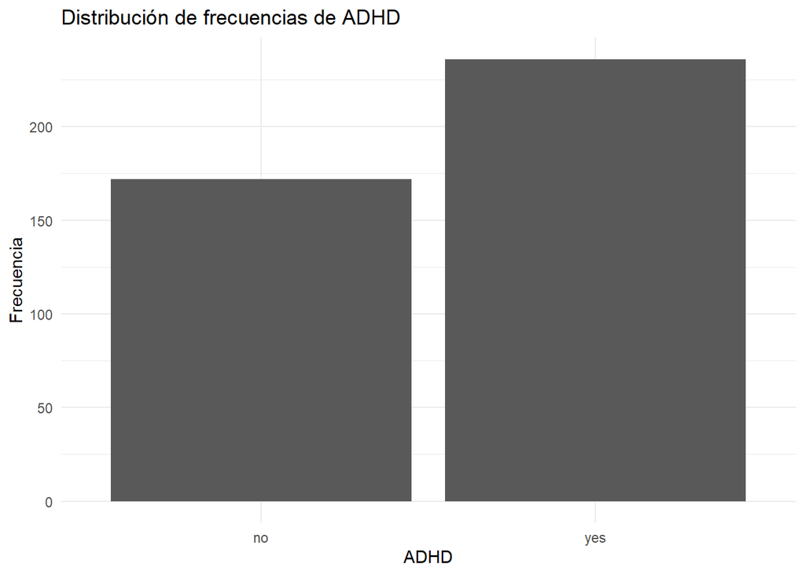

```r
anl_frec(x_relevant, "ADHD")
```

Anlizando la variable “ADHD” que describe el diagnostico **Enfermo** en la respuesta “yes” y **sano** en la respuesta “no” se puede identificar que 236 (57.84 %) de los niños esta enfermo y 172 (42.15 %) estan sanos.

**Código**

```
  cluster   n porcentage
1       1 135      33.09
2       2  72      17.65
3       3  64      15.69
4       4  57      13.97
5       5  41      10.05
6       6  39       9.56
```

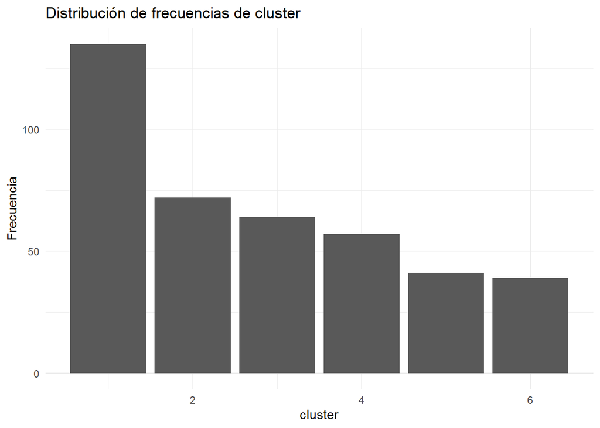

```r
anl_frec(x_relevant, "cluster")
```

La distribución de frecuencia de la variable “cluster” describe 6 **grupos de severidad** que categorizan la pertenencia de cada uno de los niños estudiados. En el primer grupo se incluyen 135 niños (33.09 %), en el segundo grupo 72 (17.65 %) niños, en el tercero grupo 64 (15.69 %) niños, en el cuarto grupo 57 (13.97 %) niños, en el quinto grupo 41 (10.05 %) niños y en el sexto grupo 39 (9.56 %) niños.

**Código**

```
  Sex   n porcentage
1   M 233      57.11
2   F 175      42.89
```

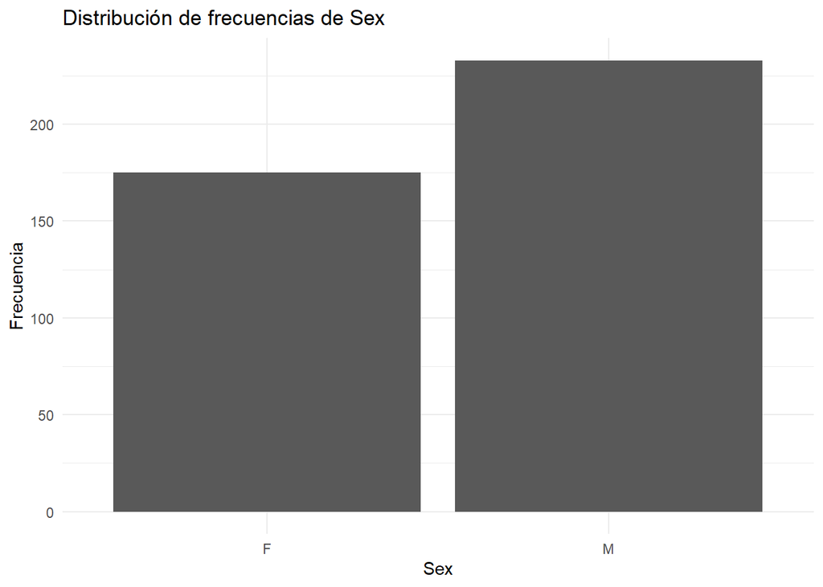

```r
anl_frec(x_relevant, "Sex")
```

En el analisis de distribucion de la variable **Sex** que describre el genero de los niños estudiados, encontramos que 233 (57.11 %) son catalogados como “M” genero masculino y 175 catalogadas como “F” que se describe como genero femenino.

## Ejercicio 2 (10 puntos)

Es posible afirmar que *la mayoría* de las personas afectadas por la enfermedad corresponde a *menores de edad*? Visualice sus resultados. Determine qué patrón ocurre al desagregar la información por `Sex`. Concluya.

**Código**

```r
## lectura de datos
library(dplyr)
x_relevant <- x %>%
  select(ADHD, Age) %>%
  mutate("Menor_de_edad" = ifelse(Age<18, "yes","no"))
## aquí va el código
head(x_relevant)
```

```
  ADHD Age Menor_de_edad
1  yes   7           yes
2   no  35            no
3   no  39            no
4  yes   6           yes
5   no  12           yes
6   no  39            no
```

**Código**

```r
frec_menor_de_edad <- x_relevant %>%
  count(Menor_de_edad) %>%
  mutate(Porcentage = round( n / sum(n) * 100,2))
print(frec_menor_de_edad)
```

```
  Menor_de_edad   n Porcentage
1            no 246      60.29
2           yes 162      39.71
```

**Código**

```r
tabla_cont<-table(x_relevant$ADHD,x_relevant$Menor_de_edad)
tabla_marg<-addmargins(tabla_cont)
print(tabla_marg)
```

```
       no yes Sum
  no  145  27 172
  yes 101 135 236
  Sum 246 162 408
```

**Código**

```r
tabla_por<-round(prop.table(tabla_cont)*100,2)
tabla_por_marg<-addmargins(tabla_por)
print(tabla_por_marg)
```

```
          no    yes    Sum
  no   35.54   6.62  42.16
  yes  24.75  33.09  57.84
  Sum  60.29  39.71 100.00
```

**Código**

```r
## lectura de datos
library(dplyr)
x_relevant <- x %>%
  select(ADHD, Age, Sex) %>%
  mutate("Menor_de_edad" = ifelse(Age<18, "yes","no"))
## aquí va el código
head(x_relevant)
```

```
  ADHD Age Sex Menor_de_edad
1  yes   7   F           yes
2   no  35   M            no
3   no  39   F            no
4  yes   6   M           yes
5   no  12   M           yes
6   no  39   F            no
```

**Código**

```r
tabla_cont<-table(x_relevant$ADHD,x_relevant$Menor_de_edad, x_relevant$Sex)
tabla_marg<-addmargins(tabla_cont)
#tabla_margf<-ftable(tabla_cont)
cat("ADHD / Menor de edad segmentado por Genero\n")
```

```
ADHD / Menor de edad segmentado por Genero
```

**Código**

```r
print(tabla_marg)
```

```
, ,  = F


       no yes Sum
  no   85  15 100
  yes  38  37  75
  Sum 123  52 175

, ,  = M


       no yes Sum
  no   60  12  72
  yes  63  98 161
  Sum 123 110 233

, ,  = Sum


       no yes Sum
  no  145  27 172
  yes 101 135 236
  Sum 246 162 408
```

**Código**

```r
tabla_por<-round(prop.table(tabla_cont)*100,2)
tabla_por_marg<-addmargins(tabla_por)
#tabla_por_margf<-ftable(tabla_por_marg)
cat("ADHD / Menor de edad / Genero")
```

```
ADHD / Menor de edad / Genero
```

**Código**

```r
print(tabla_por_marg)
```

```
, ,  = F


          no    yes    Sum
  no   20.83   3.68  24.51
  yes   9.31   9.07  18.38
  Sum  30.14  12.75  42.89

, ,  = M


          no    yes    Sum
  no   14.71   2.94  17.65
  yes  15.44  24.02  39.46
  Sum  30.15  26.96  57.11

, ,  = Sum


          no    yes    Sum
  no   35.54   6.62  42.16
  yes  24.75  33.09  57.84
  Sum  60.29  39.71 100.00
```

Segmentando la tabla de contingencia por genero (“Sex”), para identificar la cantidad de personas que presentan o no el diagnostico de enfermo descrito enla columna “ADHD” y si la persona es o no menor_de_edad, encontramos que en el genero maculino (M), 98 personas estan enfermos y son menores de edad, esto representa el 24.02 % y es el grupo con mayor participación. Por lo tanto en el genero masculino si es posible afirmar que la mayoria de personas afectadas por la enfermedad corresponde a menores de edad. En el genero femenino (F) no es posible afirmarlo.

## Ejercicio 3 (10 puntos)

Podemos decir que existe una *asociación* entre el `cluster` y el número de síntomas de la enfermedad? En qué `cluster` parece encontrarse la mayor cantidad de personas con `ADHD`? Cuál es el `UID` de la persona *sin* `ADHD` con el mayor número de síntomas, y el `UID` de la persona diagnosticada con `ADHD` con el menor número de síntomas?

**Código**

```r
## lectura de datos
library(dplyr)
x_relevant <- x %>%
  select(UID, cluster, ADHD, inatsymptoms, impsymptoms, hypsymptoms) %>%
  mutate(Total_sintomas = (inatsymptoms + impsymptoms + hypsymptoms))
## aquí va el código
head(x_relevant)
```

```
  UID cluster ADHD inatsymptoms impsymptoms hypsymptoms Total_sintomas
1   3       3  yes            0           1           1              2
2   1       1   no            9           2           5             16
3   2       4   no            3           1           2              6
4   7       3  yes            0           1           0              1
5   6       1   no            0           0           0              0
6   5       1   no            7           4           6             17
```

**Código**

```r
tabla_cont<-table(x_relevant$cluster,x_relevant$ADHD)
tabla_marg<-addmargins(tabla_cont)
cat("Cluster / ADHD")
```

```
Cluster / ADHD
```

**Código**

```r
print(tabla_marg)
```

```
       no yes Sum
  1   117  18 135
  2     9  63  72
  3     5  59  64
  4    27  30  57
  5     9  32  41
  6     5  34  39
  Sum 172 236 408
```

En el cluster donde se puede encontrar la mayor cantidad de personas con ADHD es el número 2, donde se identifican 63 personas con la enfermedad.

**Código**

```r
reg_max <- x_relevant %>%
  filter(ADHD == "yes")
reg_max <- reg_max %>%
  filter(Total_sintomas == max(Total_sintomas))
id_max <- reg_max$UID
cat("Los UID de las personas enfermas con el mayor número de sintomas son:", id_max, "\n")
```

```
Los UID de las personas enfermas con el mayor número de sintomas son: 51 55 84 141 151 152 176 215 287 325 352 399 402
```

**Código**

```r
reg_min <- x_relevant %>%
  filter(ADHD == "yes")
reg_min <- reg_min %>%
  filter(Total_sintomas == min(Total_sintomas))
id_min <- reg_min$UID
cat("Los UID de las personas enfermas con el menor número de sintomas son:", id_min, "\n")
```

```
Los UID de las personas enfermas con el menor número de sintomas son: 14 20 26 42 76 80 101 113 117 160 240 247 255 259 262 266 277 344 371 379 407
```

## Ejercicio 4 (10 puntos)

De acuerdo con `inatsymtoms`, quiénes son más inatentos? Los `Father`s o las `Mother`s? Determine el número de individuos `Father` con `ADHD` y compárelo con los individuos `Mother` con el diagnóstico. Es posible afirmar que en esta población los `Father`s son más inatentos que las `Mother`s? Use un nivel de significancia $alpha=0.05$ para *todas* las pruebas que considere necesario realizar.

**Código**

```r
## lectura de datos
library(dplyr)
x_relevant <- x %>%
  select(ADHD, inatsymptoms, Father, Mother)
## aquí va el código
head(x_relevant)
```

```
  ADHD inatsymptoms Father Mother
1  yes            0      1      2
2   no            9      0      0
3   no            3      0      0
4  yes            0      4      5
5   no            0      4      5
6   no            7      0      0
```

**Código**

```r
x_relevant_ADHD <- x_relevant %>%
  filter(ADHD == "yes")
head(x_relevant_ADHD)
```

```
  ADHD inatsymptoms Father Mother
1  yes            0      1      2
2  yes            0      4      5
3  yes            9      8      9
4  yes            0      8      9
5  yes            8      0      0
6  yes            0     12     13
```

**Código**

```r
tabla_FvsM_ADHD <- table(x_relevant_ADHD$Mother == 0, x_relevant_ADHD$inatsymptoms)
tabla_FvsM_ADHD
```

```
         0  1  2  3  4  5  6  7  8  9 10
  FALSE 37 17 13 10 12 14 11  6  4  6  7
  TRUE   6  4  6  8  0  7 11  5 12  8 32
```

**Código**

```r
tabla_FvsM_ADHD <- table(x_relevant_ADHD$Father == 0, x_relevant_ADHD$inatsymptoms)
tabla_FvsM_ADHD
```

```
         0  1  2  3  4  5  6  7  8  9 10
  FALSE 37 17 13 10 12 14 11  6  4  6  7
  TRUE   6  4  6  8  0  7 11  5 12  8 32
```

**Código**

```r
father_ADHD <- x_relevant %>%
  filter(Father == 0 & ADHD == "yes")
mother_ADHD <- x_relevant %>%
  filter(Mother == 0 & ADHD == "yes")

n_f<-count(father_ADHD)
cat("Padres con ADHD:",n_f$n, "\n")
```

```
Padres con ADHD: 99
```

**Código**

```r
n_m<-count(mother_ADHD)
cat("Madres con ADHD:",n_m$n, "\n")
```

```
Madres con ADHD: 99
```

Entendiendo que en la columna Father y Mother cuando el valor es cero indica que es padre o madre, se filtra el set de datos, no obstante se identifica que los resultados iguales y tienen ma misma distribución. por lo tanto no es posible afirmar que en esta población los Fathers son más inatentos que las Mother.

## Ejercicio 5 (10 puntos)

Podemos decir que existe una relación entre `Age` y `trait1` en personas menores de edad? Utilice EDA para ello. Ahora, determine si existe diferencia en la `trait1` promedio entre los individuos `Male` y `Female` menores edad diagnosticados con `ADHD`. Qué pasa si comparamos menores de edad `Male` con `ADHD` vs. `Male` sin `ADHD`? Use un nivel de significancia $\alpha=0.05$ para *todas* las pruebas que considere necesario realizar. Concluya.

**Código**

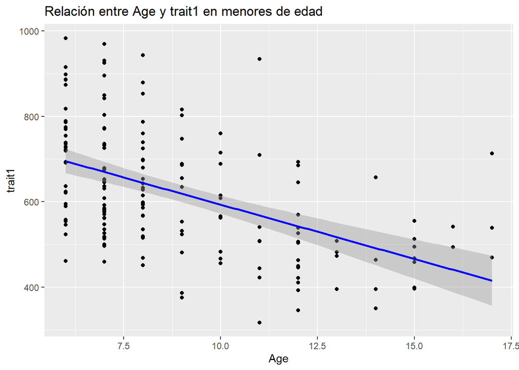

```r
## here you add some code
## aquí va el código

# Filtrar datos para menores de edad
menores <- x %>% filter(Age < 18)

# Visualizar la relación entre Age y trait1
ggplot(menores, aes(x = Age, y = trait1)) +
  geom_point() +
  geom_smooth(method = "lm", col = "blue") +
  labs(title = "Relación entre Age y trait1 en menores de edad",
       x = "Age",
       y = "trait1")
```

**Código**

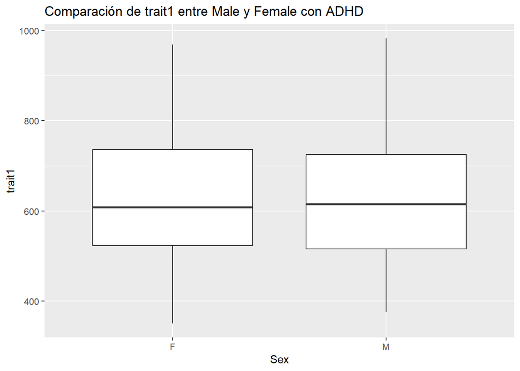

```r
# Filtrar datos para menores de edad con ADHD
menores_adhd <- menores %>% filter(ADHD == "yes")

# Comparar trait1 entre Male y Female
ggplot(menores_adhd, aes(x = Sex, y = trait1)) +
  geom_boxplot() +
  labs(title = "Comparación de trait1 entre Male y Female con ADHD",
       x = "Sex",
       y = "trait1")
```

**Código**

```r
# Realizar una prueba t para comparar trait1 entre Male y Female
t_test_sex <- t.test(trait1 ~ Sex, data = menores_adhd)
t_test_sex
```

```
    Welch Two Sample t-test

data:  trait1 by Sex
t = 0.5653, df = 58.296, p-value = 0.574
alternative hypothesis: true difference in means between group F and group M is not equal to 0
95 percent confidence interval:
 -42.93305  76.73027
sample estimates:
mean in group F mean in group M
       642.6197        625.7211
```